# Homework 10

Solutions for Questions 1 and 2 will be available after Monday, November 2, 2026. No solution will be provided for Question 3.

Use the RLT package for Questions 1 and 2: `RLT` in R or `rlt` in Python. The node-size parameter is `nmin` in R and `min_samples_leaf` in Python; both stop splitting a node when it contains at most that many observations. The candidate-predictor parameter is `mtry` in both languages. Use ordinary random forests, with reinforcement turned off.

## Question 1: Bias-variance trade-off simulation

Two important tuning parameters of random forests are node size and `mtry`. We have performed some preliminary analysis in class. The goal of this question is to perform a larger simulation study for these two tuning parameters.

Consider a regression model with five jointly normally distributed predictors. Each predictor has mean 0 and variance 1, and the correlation between any two different predictors is 0.3. The response is

$$Y=X_1+X_3+X_5+\varepsilon,
\qquad \varepsilon\sim N(0,1),$$

where the noise is independent of the predictors. Thus the true regression function is $f(\mathbf{x})=x_1+x_3+x_5$.

1. Set up a simulation study with 100 repetitions. Generate 200 test predictor vectors once and keep them fixed. In each repetition, generate 200 new training observations and use the same training data for all tuning settings. Fit 500-tree forests, drawing 200 observations with replacement for each tree. Make the following two comparisons:
   - Fix `mtry` at 3 and vary node size over $1,5,10,20,30$.
   - Fix node size at 10 and vary `mtry` over $1,2,3,4,5$.

   Leave all other fitting parameters at their defaults. Record the predictions at each test point across repetitions. For each setting, estimate the squared bias and variance at each test point, then average them over the 200 test points. Compare predictions with $f(\mathbf{x})$ when estimating bias. Produce two figures, one for each tuning parameter, showing the averaged squared bias and variance. Set a random seed and report it.
2. Discuss your results in terms of the bias-variance trade-off:
   - How does a large node size, such as 30, affect the fit in this example?
   - What are the benefits and drawbacks of using a large `mtry` value?
   - If each tree instead sampled 100 observations with replacement, would you expect the preferred node size to shift toward smaller or larger values? Explain your reasoning. You may use an additional simulation to help, but a particular pattern is not guaranteed.

part a.

```python
import numpy as np
import pandas as pd
import matplotlib.pyplot as plt
from rlt import RLT_reg

SEED = 432
rng = np.random.default_rng(SEED)

# Predictors: 5 jointly normal, mean 0, variance 1, pairwise correlation 0.3
p, rho = 5, 0.3
Sigma = np.full((p, p), rho)
np.fill_diagonal(Sigma, 1)

def f(X):                       # true regression function x1 + x3 + x5
    return X[:, 0] + X[:, 2] + X[:, 4]

n_train, n_test, n_rep = 200, 200, 100
X_test = rng.multivariate_normal(np.zeros(p), Sigma, size=n_test)   # fixed test set
f_test = f(X_test)

node_sizes = [1, 5, 10, 20, 30]
mtrys = [1, 2, 3, 4, 5]
# (study, value shown on x-axis, mtry, node size)
settings = [("node", k, 3, k) for k in node_sizes] + \
           [("mtry", m, m, 10) for m in mtrys]

pred = np.zeros((len(settings), n_rep, n_test))

for r in range(n_rep):
    X = rng.multivariate_normal(np.zeros(p), Sigma, size=n_train)
    y = f(X) + rng.normal(size=n_train)
    for s, (_, _, mtry, nmin) in enumerate(settings):   # same training data for all settings
        fit = RLT_reg(n_estimators=500, mtry=mtry, min_samples_leaf=nmin,
                      resample_prob=1, resample_replace=True,
                      random_state=SEED + r, n_jobs=1).fit(X, y)
        pred[s, r] = fit.predict(X_test)

# Squared bias and variance at each test point, then average over test points
mean_pred = pred.mean(axis=1)                              # (settings, test points)
bias2 = ((mean_pred - f_test) ** 2).mean(axis=1)
var = pred.var(axis=1, ddof=1).mean(axis=1)

res = pd.DataFrame({"study": [s[0] for s in settings],
                    "value": [s[1] for s in settings],
                    "bias2": bias2, "variance": var})
res["total"] = res.bias2 + res.variance
print(res.round(4))
```

```
  study  value   bias2  variance   total
0  node      1  0.1514    0.1970  0.3483
1  node      5  0.1536    0.1902  0.3438
2  node     10  0.1654    0.1793  0.3447
3  node     20  0.2137    0.1641  0.3778
4  node     30  0.2835    0.1594  0.4429
5  mtry      1  0.4534    0.1139  0.5673
6  mtry      2  0.2189    0.1454  0.3643
7  mtry      3  0.1654    0.1793  0.3447
8  mtry      4  0.1508    0.2055  0.3564
9  mtry      5  0.1460    0.2262  0.3722
```

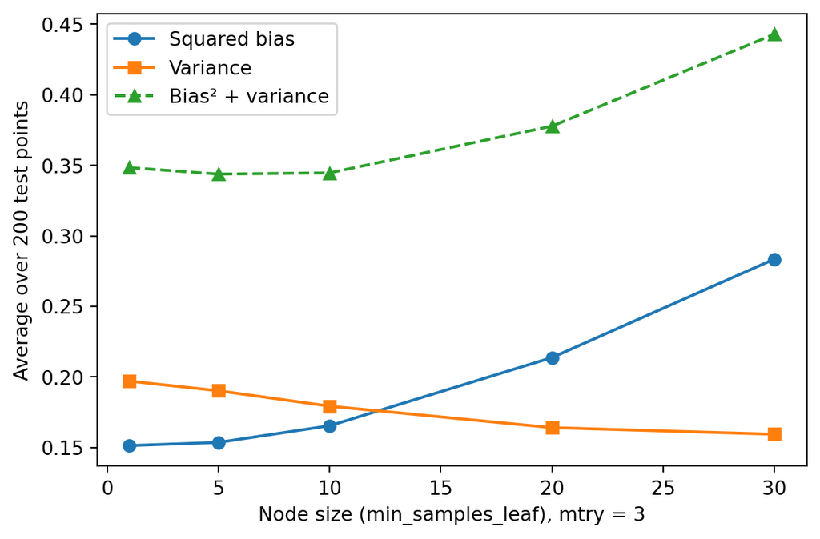

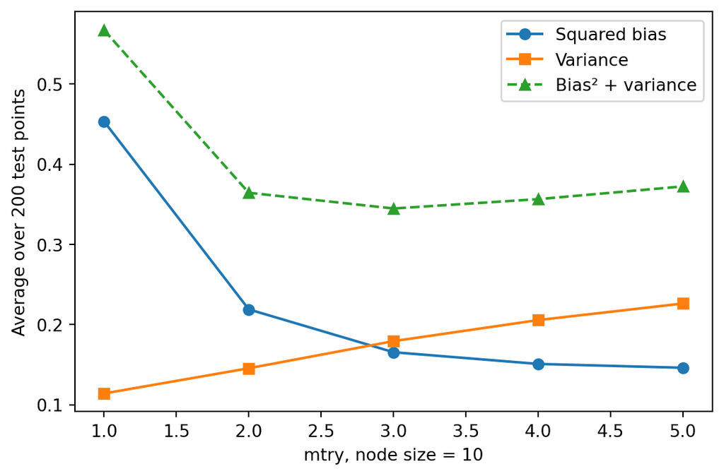

```python
# Two figures, one per tuning parameter
for study, xlab in [("node", "Node size (min_samples_leaf), mtry = 3"),
                    ("mtry", "mtry, node size = 10")]:
    d = res[res.study == study]
    plt.figure(figsize=(6, 4))
    plt.plot(d.value, d.bias2, "o-", label="Squared bias")
    plt.plot(d.value, d.variance, "s-", label="Variance")
    plt.plot(d.value, d.total, "^--", label="Bias² + variance")
    plt.xlabel(xlab)
    plt.ylabel("Average over 200 test points")
    plt.legend()
    plt.tight_layout()
    plt.show()
```

Sampling 100 instead of 200 observations per tree: I’d expect the preferred node size to shift smaller. With half the data per tree, a leaf of a given size covers a region about twice as large, so the same node size already gives a coarser fit (more bias). Also, smaller subsamples make the trees less correlated, which lowers forest variance and reduces the need for large leaves to stabilize it. Both effects point toward smaller node sizes.

## Question 2: Tuning random forests for MNIST

Use `mnist-first2000.csv.gz` from the combined ZIP. It contains 2,000 MNIST observations, with the digit label `Digit` and 784 pixel values.

- From the first 1,000 observations, keep digits 1, 6, and 7 as the training data. From the remaining 1,000 observations, keep the same digits as the test data.
- Fit PCA to the training pixels, centering but not scaling them. Use the first 20 principal components as predictors, and project the test observations using the same training means and loadings.

Complete the following tasks using RLT classification forests with 1,000 trees. For each tree, draw a bootstrap sample of the same size as the training set.

1. Fit a random forest with the default `mtry` and node-size settings. Report the out-of-bag (OOB) misclassification rate.
2. Construct a grid of `mtry` and node-size values to tune the model. Select the setting using OOB misclassification rate. Report the OOB error for each setting and the selected values. Calculate and present the selected forest’s OOB permutation variable importance for the 20 principal components. Comment on your results.
3. Apply the selected model to the test data and report the misclassification rate and confusion matrix. Use the test labels only for this final assessment.

```python
import numpy as np
import pandas as pd
from rlt import RLT_cla

SEED = 432
mnist = pd.read_csv("/Applications/UIUC/Stat432/homework/week-10/data/mnist-first2000.csv.gz", compression="gzip")
digits = [1, 6, 7]

train = mnist.iloc[:1000];  train = train[train.Digit.isin(digits)]
test  = mnist.iloc[1000:];  test  = test[test.Digit.isin(digits)]

pix = [c for c in mnist.columns if c != "Digit"]
Xtr_pix = train[pix].to_numpy(float);  ytr = train.Digit.to_numpy()
Xte_pix = test[pix].to_numpy(float);   yte = test.Digit.to_numpy()

# PCA on training pixels: center only, no scaling
center = Xtr_pix.mean(axis=0)
U, S, Vt = np.linalg.svd(Xtr_pix - center, full_matrices=False)
loadings = Vt[:20].T                       # 784 x 20

Xtr = (Xtr_pix - center) @ loadings        # training PC scores
Xte = (Xte_pix - center) @ loadings        # test projected with TRAINING means/loadings
pc_names = [f"PC{j}" for j in range(1, 21)]
```

part a.

```python
fit0 = RLT_cla(n_estimators=1000, resample_prob=1, resample_replace=True,
               random_state=SEED, n_jobs=1).fit(Xtr, ytr)
print(fit0.params_.mtry, fit0.params_.nmin)   # defaults used: 10, 5
print("OOB error:", fit0.oob_error_)
```

```
10 5
OOB error: 0.04281345565749235
```

part b.

```python
grid = pd.DataFrame([(m, k) for m in [1, 2, 4, 6, 10, 15, 20]
                            for k in [1, 5, 10, 20]],
                    columns=["mtry", "node_size"])
oob = []
for m, k in grid.itertuples(index=False):
    fit = RLT_cla(n_estimators=1000, mtry=m, min_samples_leaf=k,
                  resample_prob=1, resample_replace=True,
                  random_state=SEED, n_jobs=1).fit(Xtr, ytr)
    oob.append(fit.oob_error_)
grid["OOB_error"] = oob
print(grid.pivot(index="mtry", columns="node_size", values="OOB_error").round(4))

best = grid.loc[grid.OOB_error.idxmin()]
print(best)

# Refit the selected setting with OOB permutation importance
best_fit = RLT_cla(n_estimators=1000, mtry=int(best.mtry),
                   min_samples_leaf=int(best.node_size),
                   resample_prob=1, resample_replace=True,
                   importance="permute", random_state=SEED, n_jobs=1).fit(Xtr, ytr)
print("Selected forest OOB error:", best_fit.oob_error_)
vi = pd.Series(best_fit.feature_importances_, index=pc_names).sort_values(ascending=False)
print(vi.round(4))
```

```
node_size      1       5       10      20
mtry
1          0.0153  0.0214  0.0245  0.0275
2          0.0367  0.0336  0.0367  0.0367
4          0.0367  0.0398  0.0398  0.0367
6          0.0398  0.0367  0.0398  0.0398
10         0.0459  0.0428  0.0428  0.0459
15         0.0489  0.0459  0.0489  0.0489
20         0.0489  0.0489  0.0489  0.0520
mtry         1.000000
node_size    1.000000
OOB_error    0.015291
Name: 0, dtype: float64
Selected forest OOB error: 0.01529051987767584
PC2     0.1295
PC1     0.0948
PC3     0.0340
PC5     0.0325
PC6     0.0294
PC7     0.0245
PC11    0.0234
PC18    0.0213
PC10    0.0201
PC12    0.0186
PC16    0.0182
PC4     0.0179
PC14    0.0177
PC13    0.0151
PC20    0.0150
PC19    0.0141
PC8     0.0139
PC9     0.0135
PC17    0.0134
PC15    0.0115
dtype: float64
```

The tuning results show that mtry is the parameter that matters most for this data. OOB error rises almost steadily as mtry increases, from about 1.5–2.8% at mtry = 1 to about 5% at mtry = 20. Node size has a much smaller effect and mostly matters only at mtry = 1, where smaller leaves give slightly lower error. The selected setting is mtry = 1 and node size = 1, with an OOB error of 0.0153 (5 of 327 observations misclassified).

A small mtry likely works well here because the signal is spread across many principal components rather than concentrated in a few. With mtry = 1, each split considers only one randomly chosen component, which forces the trees to use many different PCs and makes them less correlated with each other. Averaging less-correlated trees reduces variance more effectively. This is the opposite of the pattern in Question 1, where only 3 of the 5 predictors carried signal and a small mtry caused high bias. After PCA, nearly every component carries some useful information, so restricting the candidate set costs little bias.

The permutation importance results support this. PC2 (0.1295) and PC1 (0.0948) are clearly the most important. They are the leading directions of pixel variation, explaining about 15% and 19% of the variance, and likely capture the main shape differences among 1s, 6s, and 7s, such as stroke slant, thickness, and the closed loop of a 6. After the top two, importance levels off gradually, but all 20 components have positive importance. This means the forest draws on many components, which fits with why a small mtry works well.

One caveat is that the differences between the best settings are small, only a few misclassified observations (for example, 5 versus 7 errors out of 327). Because the selected setting was chosen as the minimum over 28 settings, its OOB error is likely somewhat optimistic as an estimate of future performance.

part c.

```python
yhat = best_fit.predict(Xte)
print("Test error:", np.mean(yhat != yte))
print(pd.crosstab(pd.Series(yte, name="True"), pd.Series(yhat, name="Predicted")))
```

```
Test error: 0.015772870662460567
Predicted    1    6    7
True
1          102    0    2
6            0  106    0
7            0    3  104
```

The test error (1.58%) is very close to the selected OOB error (1.53%), so OOB was a reliable guide here. All 6s were classified correctly. The few mistakes are 1s called 7s, which makes sense since both are mostly a single vertical stroke, and 7s called 6s.

## Question 3: Planning a random-forest analysis skill

In earlier homework, some students wrote long skill files with detailed instructions, while others wrote short skills emphasizing their specific requirements or references. These approaches may perform differently depending on the AI and the task. A capable AI may already know standard ways to perform an analysis, so some instructions may be redundant, add little value, or sometimes make the analysis worse. It may be more useful to specify your personal choices for the analysis. An AI with more limited knowledge may benefit from detailed instructions that remind it of the steps to perform.

1. Write one paragraph describing how you would write a skill that directs an AI to perform a random-forest analysis and produce a report for a future dataset. Discuss how you would balance standard analysis instructions with your personal preferences, considering the AI’s capabilities.
2. Provide **10 instructions** you would consider including in the skill, **ordered from the most basic instructions to the more personal preferences**. Your list may cover computation, tuning, tables, figures, interpretation, presentation, or other aspects of a random-forest report.

You only need to discuss how the skill should be written. You are not required to write a complete skill file or test it.

1. When writing a skill for a random-forest analysis, I would keep the standard instructions short and spend most of the space on my own preferences and the requirements specific to my course. A capable AI already knows the basic workflow, like splitting data, fitting a forest, tuning mtry and node size, and reporting error. Spelling out every step adds length without adding much value, and overly detailed instructions can even make the result worse by locking the AI into a rigid procedure that doesn’t fit a new dataset. Still, I would include a few short reminders of the most important standard steps, such as keeping the test data out of tuning and setting a seed. These matter enough that I don’t want to rely on the AI remembering them, and they would also help a less capable AI that might skip them. The rest of the skill would focus on what an AI can’t guess on its own: which package and parameter names to use, how I want tables and figures to look, how long the report should be, and how I want results explained. If I were using a weaker AI, I would expand the standard section with more step-by-step detail. For a strong AI, I would trim it and let the personal preferences do most of the work.
1. Check the data before fitting: report the number of observations and predictors, the response type, missing values, and the class balance for classification.
2. Keep the test data separate from all tuning and model selection, and use it only once for the final assessment.
3. Set a random seed for every step that involves randomness and report it so the results can be reproduced.
4. Tune mtry and node size over a grid using OOB error, and report the error for every setting, not just the best one.
5. Use enough trees (at least 500) that the OOB error is stable, and fix the tree count during tuning so the comparison focuses on mtry and node size.
6. Report OOB permutation variable importance for the selected model, and note that importance shows predictive reliance, not causal effect.
7. Use the RLT package (RLT in R or rlt in Python) with reinforcement turned off, and use the course’s parameter names (mtry, nmin / min_samples_leaf).
8. Present the tuning results as a grid table (rows = mtry, columns = node size) and show the test results as a confusion matrix for classification or test MSE for regression.
9. Explain each result in two or three plain-language sentences, connecting it to the bias-variance trade-off, and avoid jargon-heavy or filler writing.
10. Keep the whole report under 10 pages as a single self-contained HTML or PDF file, putting the code in collapsible chunks so the results and interpretation come first.